# Guillermo Romera | Signature Project | DA5030 | Intro to Data Mining/Machine Learning | Term Fall 2017

```r
#Here we see how they have performed the models above in the resample data, and it is quite interesting to see that overall they have performed worse that the ones I've done at the beginning of the modelling phase. I haven't been able to get the root cause of this even I've tried many combinations, different settings and tinkered with the data.
results <- resamples(model_list1)
summary(results)
```

```
Call:
summary.resamples(object = results)

Models: glm, knn, rpart, nnet, c50, naive
Number of resamples: 25

Accuracy
        Min. 1st Qu. Median   Mean 3rd Qu.   Max. NA's
glm   0.7243  0.7537 0.7651 0.7680  0.7875 0.8059    0
knn   0.6912  0.7333 0.7551 0.7526  0.7695 0.8014    0
rpart 0.6923  0.7286 0.7417 0.7432  0.7561 0.7875    0
nnet  0.6446  0.7224 0.7456 0.7433  0.7666 0.7985    0
c50   0.6926  0.7405 0.7492 0.7503  0.7729 0.7891    0
naive 0.7185  0.7526 0.7645 0.7657  0.7850 0.8084    0

Kappa
        Min. 1st Qu. Median   Mean 3rd Qu.   Max. NA's
glm   0.3591  0.4358 0.4588 0.4613  0.4979 0.5467    0
knn   0.2865  0.3555 0.4119 0.4077  0.4484 0.5245    0
rpart 0.3183  0.3901 0.4201 0.4233  0.4603 0.5138    0
nnet  0.1215  0.3825 0.4252 0.4178  0.4779 0.5296    0
c50   0.2983  0.4056 0.4461 0.4436  0.4808 0.5304    0
naive 0.3632  0.4386 0.4848 0.4774  0.5169 0.5752    0
```

```r
set.seed(100)
#This creates a stacked caret ensemble model that will be used for pthe prediction of the outcome later on
invisible(capture.output(
stack.rf <- caretStack(model_list1, method="gbm", metric="Accuracy", trControl= trainControl(
                      method="boot",
    number=10,
    savePredictions=TRUE,
    classProbs=TRUE,
    summaryFunction=twoClassSummary))))
print(stack.rf)
```

```
A gbm ensemble of 2 base models: glm, knn, rpart, nnet, C5.0, nb

Ensemble results:
Stochastic Gradient Boosting

7072 samples
   6 predictor
   2 classes: 'X0', 'X1'

No pre-processing
Resampling: Bootstrapped (10 reps)
Summary of sample sizes: 7072, 7072, 7072, 7072, 7072, 7072, ...
Resampling results across tuning parameters:

  interaction.depth  n.trees  ROC        Sens       Spec
  1                   50      0.8456596  0.8454826  0.6328792
  1                  100      0.8456547  0.8464341  0.6330837
  1                  150      0.8455820  0.8503939  0.6288291
  2                   50      0.8465682  0.8527478  0.6244342
  2                  100      0.8469433  0.8532745  0.6225604
  2                  150      0.8470268  0.8529322  0.6243816
  3                   50      0.8472579  0.8537065  0.6181780
  3                  100      0.8473964  0.8540491  0.6207177
  3                  150      0.8469572  0.8513980  0.6257091

Tuning parameter 'shrinkage' was held constant at a value of 0.1
Tuning parameter 'n.minobsinnode' was held constant at
 a value of 10
ROC was used to select the optimal model using  the largest value.
The final values used for the model were n.trees = 100, interaction.depth = 3, shrinkage = 0.1 and n.minobsinnode = 10.
```

```r
set.seed(100)
#I predict here the outcome variable with the stacked ensemble model
model_ensemble <- predict(stack.rf, newdata=cleandb_named, type="prob")
#model_ensemble
ensemble_auc<-colAUC(model_ensemble, cleandb_named$Outcome)
ensemble_auc
```

```
               [,1]
X0 vs. X1 0.7986929
```

```r
modelt<-model_ensemble
cleandb_named$Outcome <- as.numeric(cleandb_named$Outcome == "X1")
pred.logit <- rep(1,length(modelt))
pred.logit[modelt>=0.5] <- 0
confusionMatrix(pred.logit, cleandb_named$Outcome)
```

```
Confusion Matrix and Statistics

          Reference
Prediction   0   1
         0 403  83
         1  95 182

               Accuracy : 0.7667
                 95% CI : (0.735, 0.7963)
    No Information Rate : 0.6527
    P-Value [Acc > NIR] : 5.639e-12

                  Kappa : 0.4908
 Mcnemar's Test P-Value : 0.4097

            Sensitivity : 0.8092
            Specificity : 0.6868
         Pos Pred Value : 0.8292
         Neg Pred Value : 0.6570
             Prevalence : 0.6527
         Detection Rate : 0.5282
   Detection Prevalence : 0.6370
      Balanced Accuracy : 0.7480

       'Positive' Class : 0
```

```r
ensemble_acc<-mean(pred.logit==cleandb_named$Outcome)
rmse_ensemble<- sqrt(mean((cleandb_named$Outcome-ensemble_auc)^2))
rmse_ensemble
```

```
[1] 0.6560719
```

```r
#Conclusion: Quite odd that the model ensemble hasn't proved as useful as I first expected, more considering that it would counter the lack of data in this given data frame. Another issue with the model ensemble is that it clasifies quite a lot of cases false negative, and considering we are in the medical field that might be an issue.
```

STAGE FIVE - EVALUATION

```r
comparison_models
```

|  | Models | AUC | RMSE | Accuracy |
| --- | --- | --- | --- | --- |
| 1 | glm | 0.7267940 | 1.0341483 | 0.7758847 |
| 2 | knn | 0.7402440 | 1.0297030 | 0.7876802 |
| 3 | knn_norm | 0.7036334 | 1.0104305 | 0.7640891 |
| 4 | ANN | 0.7309654 | 1.1087641 | 0.7680210 |
| 5 | C50 | 0.7054861 | 0.5957974 | 0.7745740 |
| 6 | naive | 0.7644427 | 0.6329958 | 0.7916121 |
| 7 | Rpart1 | 0.8187618 | 0.6700377 | 0.8348624 |
| 8 | rpart_age | 0.7719528 | 0.5961825 | 0.7061264 |
| 9 | rpart_pregnancies | 0.8296199 | 0.6519471 | 0.7926764 |
| 10 | rpart_bmi | 0.7942333 | 0.6177039 | 0.7408502 |

[output cut: 3 more lines]

```r
comparison_dummy<- cbind.data.frame( c(1,2,3,4,5,6,7,8,9,10,11,12,13))
colnames(comparison_dummy)<- c("model")
comp<-cbind.data.frame(comparison_models,comparison_dummy)
par(mfrow=c(1,3))
plot(comp$model,comp$AUC,
     main= "Models vs AUC",
     xlab= "AUC",
     ylab= "Models",
     col= "blue", pch = 19, cex = 1, lty = "solid", lwd = 2)
text(comp$model, comp$AUC, labels=comp$Model, cex= 0.7, pos=3)
```

```r
plot(comp$model,comp$Accuracy,
     main= "Models vs Accuracy",
     xlab= "Accuracy",
     ylab= "Models",
     col= "blue", pch = 19, cex = 1, lty = "solid", lwd = 2)
text(comp$model, comp$Accuracy, labels=comp$Model, cex= 0.7, pos=3)
```

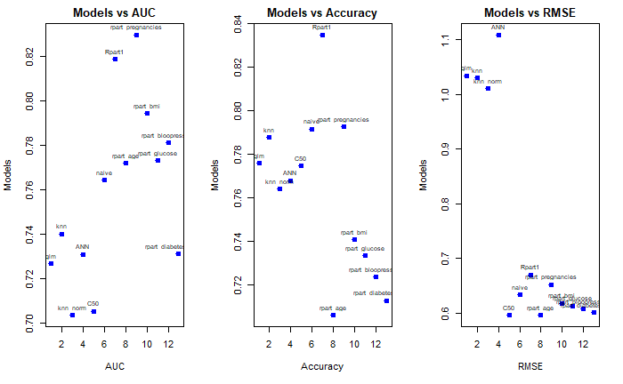

```r
plot(comp$model,comp$RMSE,
     main= "Models vs RMSE",
     xlab= "RMSE",
     ylab= "Models",
     col= "blue", pch = 19, cex = 1, lty = "solid", lwd = 2)
text(comp$model, comp$RMSE, labels=comp$Model, cex= 0.7, pos=3)
```

```r
#This plot allows a better visualization of the results, and as we can se my first choice of using the rpart decision tree might be the better option in this case, while other models perform better than that model in some areas the beneficial side of the first decision tree model (rpart) is that it is somewhat consistent across the board.
#Despite the model being rather decent, it needs to be taken into that when it comes to diabetes our data set is most likely not enough to make a proper prediction since some other markers might be needed, or even more data so the models can be trained better.
```

Assessment of data mining results :

Given the results I have obtained with the models performance I would say this has been a success, two out the 5 initial models have performed with a decent accuracy levels and what’s is better one of them shows that most of the error it has are false positive, and given that we are working within the medical field this is definetely better than false negative.

On the other hand my own personal project which was improve my understanding of Machine Learning and make a good signarute project has been quite a success, although unfortunately I’m never happy with my work and I always think there’s something to improve, the project from my perserpective have come out good.

Approved models :

My approved models in this case would be the Rpart model with and without the derived Pregnancy feature and the Naive Bayes model, all these three models have proven rather successful at achieving good results.

Decision:

Time is of the essence and how it happens in the real world I have filled my alloted time to work on this project so it has to be move on to deployment

List of possible actions:

If I had more time I would not deploy this, I would indeed try to improve it with more models or with some other features but as I mentiond in the decision it has to be deployed anyways due to time constraints

STAGE SIX DEPLOYMENT

Final report:

The activities have been documented

Final presentation:

Experience documentation:

Major pitfalls I have encountered is for the most part the lack of the experience on what to do when certain problems arise and the big amount of confugurations and setting that are possible for a given model or data set. Another pitfall it would be organization, while I think I have organized myself quite well to a certain extent, as it happens in the real world, organizing things takes a lot of time and if you lack the experience and practice it can be a very time consuming process. Overall it has been quite the experience to produce a report like this, very enjoyable but a lot of hard work at the same time

UNUSED CODE

```r
#This is data imputation by KNN and MICE algorithm but due to the lack of enough data I have deciced to leave it as a part of the code but not run it with the rest of the chunks


sb1 <- na.omit(db1)
sb2<-sb1

#The first method of imputation will be by a KNN model and then a MICE decision tree
#I will impute some random missing values to the data so I can see how well this method performs with a working data set
set.seed(100)
sb1[sample(1:nrow(sb1), 30), "Insulin"] <- NA
sb1[sample(1:nrow(sb1), 30), "SkinThickness"] <- NA

library(DMwR)
knnOutput <- knnImputation(sb1[, !names(sb1) %in% "Outcome"], k=20)
anyNA(knnOutput)

actuals <- sb2$Insulin[is.na(sb1$Insulin)]
predicteds <- knnOutput[is.na(sb1$Insulin), "Insulin"]
regr.eval(actuals, predicteds)

actuals <- sb2$SkinThickness[is.na(sb1$SkinThickness)]
predicteds <- knnOutput[is.na(sb1$SkinThickness), "SkinThickness"]
regr.eval(actuals, predicteds)


library(mice)
miceMod <- mice(sb1[, !names(sb1) %in% "Outcome"], method="rf")  # perform mice imputation, based on random forests.
miceOutput <- complete(miceMod)  # generate the completed data.
anyNA(miceOutput)


actuals <- sb2$Insulin[is.na(sb1$Insulin)]
predicteds <- miceOutput[is.na(sb1$Insulin), "Insulin"]
regr.eval(actuals, predicteds)


actuals <- sb2$SkinThickness[is.na(sb1$SkinThickness)]
predicteds <- miceOutput[is.na(sb1$SkinThickness), "SkinThickness"]
mean(actuals != predicteds)

library(rpart)
class_mod <- rpart(Insulin ~ . - Outcome, data=sb1[!is.na(sb1$Insulin), ], method="anova", na.action=na.omit)

anova_mod <- rpart(SkinThickness ~ . - Outcome, data=sb1[!is.na(sb1$SkinThickness), ], method="anova", na.action=na.omit)
rad_pred <- predict(class_mod, sb1[is.na(sb1$Insulin), ])
ptratio_pred <- predict(anova_mod, sb1[is.na(sb1$SkinThickness), ])

actuals <- sb2$SkinThickness[is.na(sb1$SkinThickness)]
predicteds <- ptratio_pred
regr.eval(actuals, predicteds)

actuals <- sb2$Insulin[is.na(sb1$Insulin)]
predicteds <- ptratio_pred
mean(actuals != predicteds)


#Conclusion: It seems these method have performed rather bad given our data, I don't think it would be safe to impute the values with these methods as their predictions are not good enough. Because of this it seems there are only two methods left to deal with all this missing data. 1. Imputing the missing data with its mean, that after some research I have these ahs been a comon practice with this data set or 2. Deleting the columns with missing values and building the predictive models over that.

normalize <- function(x) {
return ((x - min(x)) / (max(x) - min(x))) }
```

```r
######UNUSED CODE



######Ensemble Model Using Caret Package

#Although we have some decent accuracies, the best being the decision trees we sometimes can apply ensemble models to see if the accuracy can be improved over the original models. In here I will perform three different ways of model ensemble and see which one yields the best result and see if that's an improvement over the rest of the models

#The first model ensemble will be performe with the careEnsemble package and I will be running a what is called greedy ensemble, I will put them all together and see the improvement, if there is one.

#I've seen this done a in a few examples but I didn't use it since I was not sure the purpose of it, now after running the ensemble model I udnerstand that it has to be performed in order for the function to work (caret will output an error "suggesting" you to use it)
cleandb_named<-cleandb
cleandb_named1<-cleandb1
cleandb_named$Outcome<-factor(make.names(cleandb$Outcome))
cleandb_named1$Outcome<-factor(make.names(cleandb_named1$Outcome))

#set.seed(60)
library(caretEnsemble)
my_control <- trainControl(
  method="boot",
  number=10,
  savePredictions="final",
  classProbs=TRUE,
  index=createResample(cleandb_named1$Outcome, 25),
  summaryFunction=twoClassSummary
  )

model_list1 <- caretList(
  Outcome~., data=cleandb_named1,
  trControl=my_control,
  methodList=c("glm","knn","nnet", "rpart")
  )

#While the correlation for these models is not the best, as for these cases a lower correlations is better, is not terrible either so I will procceed to perform a greedy ensemble
modelCor(resamples(model_list1))

#Well this is good news, in here we already see a small improvement over the models I have performed before. The two models that have shown improvement is the glm and the ann, while the deicison tree has actually performed worse than by itself
greedy_ensemble <- caretEnsemble(
  model_list1,
  metric="ROC",
  trControl=trainControl(
    number=10,
    summaryFunction=twoClassSummary,
    classProbs=TRUE
    ))
summary(greedy_ensemble)


library("caTools")
ensemble1_pred <- lapply(model_list1, predict, newdata=cleandb_named1, type="prob")
ensemble1_pred <- lapply(ensemble1_pred, function(x) x[,"X1"])
ensemble1_pred  <- data.frame(ensemble1_pred)
ens_preds <- predict(greedy_ensemble, newdata=cleandb_named1, type="prob")
ensemble1_pred$ensemble <- ens_preds

#Interestingly enough it seems that KNN performs better than the ensemble model, also ANN as performed better too, while the decision tree has performed worse. This might by cause by the correlation between the different models.
#I will try to do different runs while substracting some models and see if it improves or not
colAUC(ensemble1_pred, cleandb_named1$Outcome)

pred.logit <- rep("X1",length(ensemble1_pred$ensemble))
pred.logit[ensemble1_pred$ensemble>=0.5] <- "X0"
confusionMatrix(cleandb_named$Outcome, pred.logit)


#conclusion: Unfortunately and not what I expected the ensemble model performs worse than their models, I've noticed that the KNN algorithm outputs a high AUC value making it the best model within the ensemble. The only moment where the ensemble model is better is by using the ANN and the decision tree, which interesting enough those two models have performe rather well in theri first runs above

######Stacked Ensemble Model Using Caret Package

#Now the second ensemble model I will be using is an stacked ensemble model, what this does is make a collection of all the predictive models so it should imrpvoe over the singel models
glm_ensemble <- caretStack(
  model_list1,
  method="rpart",
  metric="ROC",
  trControl=trainControl(
    method="boot",
    number=10,
    savePredictions="final",
    classProbs=TRUE,
    summaryFunction=twoClassSummary
  )
)


model_preds2 <- ensemble1_pred
model_preds2$ensemble <- predict(glm_ensemble, newdata=cleandb_named, type="prob")
CF <- coef(glm_ensemble$ens_model$finalModel)[-1]
colAUC(model_preds2, cleandb_named$Outcome)

#Again this stacked ensemble model doesn't perform better than their individual aprts, and for some odd reason that I haven't been able to figure out KNN yields by far better results than any other model

######Stacked Ensemble Model Using Caret Package and GBM (Gradient Boosting)

#Now this next ensemble model I am using a GRadient Boosting to see if we can build a stronger ensemble model that outperforms the rest of the other models.

library("gbm")
gbm_ensemble <- caretStack(
  model_list1,
  method="gbm",
  verbose=FALSE,
  tuneLength=10,
  metric="ROC",
  trControl=trainControl(
    method="boot",
    number=10,
    savePredictions="final",
    classProbs=TRUE,
    summaryFunction=twoClassSummary
  )
)
print(gbm_ensemble)
model_preds3 <-ensemble1_pred
model_preds3$ensemble <- predict(gbm_ensemble, newdata=cleandb_named1, type="prob")
colAUC(model_preds3, cleandb_named1$Outcome)

#And again, not even this ensemble model performs better than any of the other models

#Conclusion: It is indeed odd that the ensemble models do not outperform the rest of the models, and for some reason even after some time tinkering with the algorithms I haven't been able to figure it out, although in favour of this result I must say it's not the oddest (I had to look up this word, but apparently is correct) result I've seen this semester. For now and after multiple tries to find the root and cause of this, I have decided that maybe this given data is not ideal to make a stacked model, or the small amount of data present doesn't allow to make a good ensemble model, although that doesn't seem to be very logical since one would think that using ensemble model could be a solution for small datasets
```